# Analyse exploratoire

### Projet 4: Anticipez les besoins en consommation électrique de bâtiments

- Lien vers les données : https://www.kaggle.com/city-of-seattle/sea-building-energy-benchmarking#2015-building-energy-benchmarking.csv
- Lien vers les significations des colonnes : : https://data.seattle.gov/dataset/2016-Building-Energy-Benchmarking/2bpz-gwpy
- Lien vers Energy Star score : https://www.energystar.gov/buildings/facility-owners-and-managers/existing-buildings/use-portfolio-manager/interpret-your-results/what

```python
import numpy as np
import pandas as pd
import matplotlib.pyplot as plt
import matplotlib.gridspec as gridspec
import seaborn as sns
sns.set()
import os
```

```python
pd.set_option('display.max_columns', 60)
pd.set_option('display.max_rows', 1000)
```

#### Récupération des données

```python
data_2015 =pd.read_csv("2015-building-energy-benchmarking.csv")
```

```python
data_2016 =pd.read_csv("2016-building-energy-benchmarking.csv")
```

#### Exploration initiale des données

```python
def shape(dataframe):
    "Calcule et affiche la forme de dataframe et le taux de remplissage"

    # Obtenir le nombre de lignes et de colonnes dans le dataframe
    nb_rows, nb_columns = dataframe.shape
    print("\nLe dataFrame a {} lignes et {} colonnes.".format(nb_rows,nb_columns))

    # Obtenir le nombre de données non-Nan dans le dataframe
    nb_data = dataframe.describe(include='all').loc["count"].sum()

    # calcul du taux de remplissage en arrondissant à 2 décimales
    import math
    filling_rate = math.floor(nb_data*10000 / (nb_rows * nb_columns))/10000
    print("Le taux de remplissage global du DataFrame est de : {:.2%}".format(filling_rate))

    # calcul des valeurs manquantes
    nb_missing = int((nb_rows * nb_columns) - nb_data)
    print("Il y a {} valeurs manquantes sur {}.".format(nb_missing, int(nb_rows * nb_columns)))
```

```python
shape(data_2015)
shape(data_2016)
```

```
Le dataFrame a 3340 lignes et 47 colonnes.
Le taux de remplissage global du DataFrame est de : 83.11%
Il y a 26512 valeurs manquantes sur 156980.

Le dataFrame a 3376 lignes et 46 colonnes.
Le taux de remplissage global du DataFrame est de : 87.15%
Il y a 19952 valeurs manquantes sur 155296.
```

```python
data_2015.head(1)
```

|  | OSEBuildingID | DataYear | BuildingType | PrimaryPropertyType | PropertyName | TaxParcelIdentificationNumber | Location | CouncilDistrictCode | Neighborhood | YearBuilt | NumberofBuildings | NumberofFloors | PropertyGFATotal | PropertyGFAParking | PropertyGFABuilding(s) | ListOfAllPropertyUseTypes | LargestPropertyUseType | LargestPropertyUseTypeGFA | SecondLargestPropertyUseType | SecondLargestPropertyUseTypeGFA | ThirdLargestPropertyUseType | ThirdLargestPropertyUseTypeGFA | YearsENERGYSTARCertified | ENERGYSTARScore | SiteEUI(kBtu/sf) | SiteEUIWN(kBtu/sf) | SourceEUI(kBtu/sf) | SourceEUIWN(kBtu/sf) | SiteEnergyUse(kBtu) | … |
| --- | --- | --- | --- | --- | --- | --- | --- | --- | --- | --- | --- | --- | --- | --- | --- | --- | --- | --- | --- | --- | --- | --- | --- | --- | --- | --- | --- | --- | --- | --- |
| 0 | 1 | 2015 | NonResidential | Hotel | MAYFLOWER PARK HOTEL | 659000030 | {'latitude': '47.61219025', 'longitude': '-122... | 7 | DOWNTOWN | 1927 | 1 | 12.0 | 88434 | 0 | 88434 | Hotel | Hotel | 88434.0 | NaN | NaN | NaN | NaN | NaN | 65.0 | 78.9 | 80.3 | 173.5 | 175.1 | 6981428.0 | … |

```python
data_2016.head(1)
```

|  | OSEBuildingID | DataYear | BuildingType | PrimaryPropertyType | PropertyName | Address | City | State | ZipCode | TaxParcelIdentificationNumber | CouncilDistrictCode | Neighborhood | Latitude | Longitude | YearBuilt | NumberofBuildings | NumberofFloors | PropertyGFATotal | PropertyGFAParking | PropertyGFABuilding(s) | ListOfAllPropertyUseTypes | LargestPropertyUseType | LargestPropertyUseTypeGFA | SecondLargestPropertyUseType | SecondLargestPropertyUseTypeGFA | ThirdLargestPropertyUseType | ThirdLargestPropertyUseTypeGFA | YearsENERGYSTARCertified | ENERGYSTARScore | … |
| --- | --- | --- | --- | --- | --- | --- | --- | --- | --- | --- | --- | --- | --- | --- | --- | --- | --- | --- | --- | --- | --- | --- | --- | --- | --- | --- | --- | --- | --- | --- |
| 0 | 1 | 2016 | NonResidential | Hotel | Mayflower park hotel | 405 Olive way | Seattle | WA | 98101.0 | 0659000030 | 7 | DOWNTOWN | 47.6122 | -122.33799 | 1927 | 1.0 | 12 | 88434 | 0 | 88434 | Hotel | Hotel | 88434.0 | NaN | NaN | NaN | NaN | NaN | 60.0 | … |

```python
data_2015.describe(include=['O']).T
```

|  | count | unique | top | freq |
| --- | --- | --- | --- | --- |
| BuildingType | 3340 | 7 | NonResidential | 1461 |
| PrimaryPropertyType | 3340 | 27 | Low-Rise Multifamily | 998 |
| PropertyName | 3340 | 3287 | WAREHOUSE | 9 |
| TaxParcelIdentificationNumber | 3338 | 3245 | 3224049012 | 5 |
| Location | 3340 | 3298 | {'latitude': '47.66375728', 'longitude': '-122... | 5 |
| Neighborhood | 3340 | 13 | DOWNTOWN | 578 |
| ListOfAllPropertyUseTypes | 3213 | 442 | Multifamily Housing | 862 |
| LargestPropertyUseType | 3204 | 56 | Multifamily Housing | 1598 |
| SecondLargestPropertyUseType | 1559 | 47 | Parking | 881 |
| ThirdLargestPropertyUseType | 560 | 41 | Retail Store | 107 |
| YearsENERGYSTARCertified | 110 | 61 | 2016 | 20 |
| DefaultData | 3339 | 2 | No | 2791 |
| Comment | 13 | 13 | Under construction starting 6/2015 (old buildi... | 1 |
| ComplianceStatus | 3340 | 2 | Compliant | 3337 |
| Outlier | 84 | 2 | High Outlier | 46 |

```python
data_2016.describe(include=['O']).T
```

|  | count | unique | top | freq |
| --- | --- | --- | --- | --- |
| BuildingType | 3376 | 8 | NonResidential | 1460 |
| PrimaryPropertyType | 3376 | 24 | Low-Rise Multifamily | 987 |
| PropertyName | 3376 | 3362 | Northgate Plaza | 3 |
| Address | 3376 | 3354 | 2203 Airport Way S | 4 |
| City | 3376 | 1 | Seattle | 3376 |
| State | 3376 | 1 | WA | 3376 |
| TaxParcelIdentificationNumber | 3376 | 3268 | 1625049001 | 8 |
| Neighborhood | 3376 | 19 | DOWNTOWN | 573 |
| ListOfAllPropertyUseTypes | 3367 | 466 | Multifamily Housing | 866 |
| LargestPropertyUseType | 3356 | 56 | Multifamily Housing | 1667 |
| SecondLargestPropertyUseType | 1679 | 50 | Parking | 976 |
| ThirdLargestPropertyUseType | 596 | 44 | Retail Store | 110 |
| YearsENERGYSTARCertified | 119 | 65 | 2016 | 14 |
| ComplianceStatus | 3376 | 4 | Compliant | 3211 |
| Outlier | 32 | 2 | Low outlier | 23 |

On va regrouper les deux fichiers de 2015 et 2016. Pour cela, il faut vérifier si les deux bases de données sont homogènes.

#### Homogénéisation des fichiers

#### Analyse des colonnes

L'agrégation des données de 2015 et de 2016 nécessitera de gérer les données dupliquées.

```python
print("\nNom des {} colonnes communes :\n".format(len(set(data_2015)&set(data_2016))), set(data_2015)&set(data_2016))
print("\nNom des {} colonnes uniquement dans les données 2015 :\n".format(len(set(data_2015)-set(data_2016))), set(data_2015)-set(data_2016))
print("\nNom des {} colonnes uniquement dans les données 2016 :\n".format(len(set(data_2016)-set(data_2015))), set(data_2016)-set(data_2015))
```

```
Nom des 37 colonnes communes :
 {'YearsENERGYSTARCertified', 'SiteEUIWN(kBtu/sf)', 'Electricity(kWh)', 'ENERGYSTARScore', 'NumberofFloors', 'Electricity(kBtu)', 'PrimaryPropertyType', 'LargestPropertyUseTypeGFA', 'SteamUse(kBtu)', 'SourceEUIWN(kBtu/sf)', 'ComplianceStatus', 'DefaultData', 'SiteEUI(kBtu/sf)', 'YearBuilt', 'ThirdLa…

Nom des 10 colonnes uniquement dans les données 2015 :
 {'City Council Districts', 'GHGEmissionsIntensity(kgCO2e/ft2)', '2010 Census Tracts', 'Seattle Police Department Micro Community Policing Plan Areas', 'GHGEmissions(MetricTonsCO2e)', 'Location', 'Comment', 'OtherFuelUse(kBtu)', 'Zip Codes', 'SPD Beats'}

Nom des 9 colonnes uniquement dans les données 2016 :
 {'Longitude', 'City', 'ZipCode', 'Address', 'State', 'TotalGHGEmissions', 'Latitude', 'Comments', 'GHGEmissionsIntensity'}
```

Nous constatons que certaines colonnes spécifiques ont en fait la même sémantique. Par exemple :

- La colonne 'Comment' de 2015 correspond à la colonne 'Comments' de 2016
- La colonne 'Zip Codes' de 2015 correspond à la colonne 'ZipCode' de 2016
- La colonne 'GHGEmissionsIntensity(kgCO2e/ft2)' de 2015 correspond à la colonne 'GHGEmissionsIntensity' de 2016
- La colonne 'GHGEmissions(MetricTonsCO2e)' de 2015 correspond à la colonne 'TotalGHGEmissions' de 2016

```python
data_2015[['GHGEmissions(MetricTonsCO2e)','GHGEmissionsIntensity(kgCO2e/ft2)']].describe()
```

|  | GHGEmissions(MetricTonsCO2e) | GHGEmissionsIntensity(kgCO2e/ft2) |
| --- | --- | --- |
| count | 3330.000000 | 3330.000000 |
| mean | 110.094102 | 0.985339 |
| std | 409.450179 | 1.637172 |
| min | 0.000000 | 0.000000 |
| 25% | 9.265000 | 0.080000 |
| 50% | 32.740000 | 0.460000 |
| 75% | 88.642500 | 1.180000 |
| max | 11824.890000 | 31.380000 |

```python
data_2016[['TotalGHGEmissions','GHGEmissionsIntensity']].describe()
```

|  | TotalGHGEmissions | GHGEmissionsIntensity |
| --- | --- | --- |
| count | 3367.000000 | 3367.000000 |
| mean | 119.723971 | 1.175916 |
| std | 538.832227 | 1.821452 |
| min | -0.800000 | -0.020000 |
| 25% | 9.495000 | 0.210000 |
| 50% | 33.920000 | 0.610000 |
| 75% | 93.940000 | 1.370000 |
| max | 16870.980000 | 34.090000 |

#### Renommer les colonnes avec la même sémantique

```python
# Renommer les colonnes avec la même sémantique, pour adopter les noms de la base de données 2016
data_2015 = data_2015.rename(columns={
    'GHGEmissions(MetricTonsCO2e)':"TotalGHGEmissions",
    'Comment':'Comments',
    'Zip Codes':'ZipCode',
    'GHGEmissionsIntensity(kgCO2e/ft2)':'GHGEmissionsIntensity',
})
```

#### Décompactage des données de localisation de 2015

Nous constatons aussi que certaines colonnes spécifiques ont été reformatées. Ainsi, la colonne 'Location' de 2015 a été séparée en plusieurs colonnes en 2016 :

- State
- City
- Address
- Longitude
- Latitude
- ZipCode

```python
data_2015['Location'][0]
```

```
'{\'latitude\': \'47.61219025\', \'longitude\': \'-122.33799744\', \'human_address\': \'{"address": "405 OLIVE WAY", "city": "SEATTLE", "state": "WA", "zip": "98101"}\'}'
```

Nous allon d'abord suppprimer les colonnes 'State', 'City', 'Address', 'ZipCode' des données 2016

```python
data_2016 = data_2016.drop(['State', 'City', 'Address','ZipCode'], axis=1)
```

Nous allons donc travailler cette variable pour extraire chacune des variables imbriquées :

```python
x = data_2015['Location'].str.split(pat=", ", expand=True)
```

```python
x[0].str.replace('[^\d\.]', '')
```

```
0       47.61219025
1       47.61310583
2       47.61334897
3       47.61421585
4        47.6137544
           ...
3335    47.59950256
3336    47.65752471
3337    47.61649845
3338    47.68396954
3339    47.68396954
Name: 0, Length: 3340, dtype: object
```

```python
x[1].str.replace('[^\d\.]', '')
```

```
0       122.33799744
1       122.33335756
2       122.33769944
3       122.33660889
4        122.3409238
            ...
3335    122.32034302
3336     122.3160159
3337    122.33770787
3338     122.2874088
3339     122.2874088
Name: 1, Length: 3340, dtype: object
```

```python
data_2015['Latitude'] = x[0].str.replace('[^\d\.]', '')
data_2015['Longitude'] = x[1].str.replace('[^\d\.\-]', '')
```

Nous avons décompacter cette variable en conservant uniquement les colonnes correspondant à celles de 2016, c'est à dire 'latitude, longitude'. Renommons les de la même façon.

### Concaténation

```python
data = pd.concat([data_2015, data_2016], sort=False)
shape(data)
```

```
Le dataFrame a 6716 lignes et 49 colonnes.
Le taux de remplissage global du DataFrame est de : 78.70%
Il y a 70080 valeurs manquantes sur 329084.
```

#### - Suppression des lignes correspondant à des habitations

Il est précisié dans le projet que seuls les bâtiments non destinés à l'habitation seront étudiés. Nous allons donc supprimer les lignes correspondant à des habitations en nous basant sur la variable BuildingType

```python
data['BuildingType'].unique()
```

```
array(['NonResidential', 'Nonresidential COS', 'Multifamily MR (5-9)',
       'SPS-District K-12', 'Multifamily LR (1-4)', 'Campus',
       'Multifamily HR (10+)', 'Nonresidential WA'], dtype=object)
```

```python
data = data[~data['BuildingType'].str.contains("Multifamily")]
data['BuildingType'].unique()
```

```
array(['NonResidential', 'Nonresidential COS', 'SPS-District K-12',
       'Campus', 'Nonresidential WA'], dtype=object)
```

```python
data.shape
```

```
(3318, 49)
```

#### -Fusion des lignes correspondant à des bâtiments dupliqués

Nous identifions les bâtiments dupliqués sur la base de l'identifiant 'OSEBuildingID'.

Nous fusionnons ensuite les lignes et supprimons les doublons.

```python
data['OSEBuildingID'].duplicated().sum()
```

```
1620
```

```python
def duplicates_merging(dataframe, keys):
    "Cette fonction traite les lignes dupliquées dans le dataframe, en fonction d'un sous-ensemble des colonnes"

    # Vérifier s'il y a des lignes en double
    duplicates_mask = dataframe.duplicated(subset=keys, keep=False)
    if True not in list(duplicates_mask.unique()):
        print("No duplicates.")
        return dataframe

    print("Nombre de lignes en double :", len(dataframe[duplicates_mask]))

    # Filtrage du dataframe pour conserver que les lignes dupliquées
    duplicates_mask = dataframe.duplicated(subset=keys, keep=False)
    duplicates_df = dataframe[duplicates_mask]

    # Grouper par sous-ensemble des colonnes utilisées pour la clé, sort=False pour accélérer
    gb = duplicates_df.groupby(keys, sort=False)

    # Initialisation du dataframe agrégé
    agg_df = pd.DataFrame()

    # Identification des colonnes numériques et non numériques
    numeric_columns = list(dataframe.select_dtypes(include=[np.number]).columns.values)

    # définition de la fonction d'agrégation pour les colonnes non numériques
    def agg_mode(x): m = pd.Series.mode(x); return m.values[0] if not m.empty else np.nan

    # Itérer sur les colonnes
    for column in dataframe.columns:

        # Calculer la moyenne de chaque groupe pour les colonnes numériques
        if column in numeric_columns:
            agg_col = gb[column].agg('mean')

        # Calculer le mode de chaque groupe pour les colonnes numériques
        else:
            agg_col = gb[column].agg(agg_mode)

        # ajouter la colonne agrégée au dataframe agrégé
        agg_df = pd.concat([agg_df, agg_col], axis=1, sort=True)

    # Suppression de tous les doublons
    dataframe_cleaned = dataframe.drop_duplicates(subset=keys, keep=False)

    # Concaténer le dataframe sans doublons et les lignes agrégées pour les doublons
    result = dataframe_cleaned.append(agg_df, ignore_index=True, sort=False)

    print("Shape après le traitement des doublons  :", result.shape)
    return result
```

```python
dataframe = data
keys = ['OSEBuildingID']

data = duplicates_merging(dataframe, keys)
shape(data)
```

```
Nombre de lignes en double : 3240
```

```
Shape après le traitement des doublons  : (1698, 49)

Le dataFrame a 1698 lignes et 49 colonnes.
Le taux de remplissage global du DataFrame est de : 83.96%
Il y a 13339 valeurs manquantes sur 83202.
```

#### -Suppression des colonnes inutiles

```python
data = data.drop(['DefaultData','Location',
              'PropertyName','City Council Districts',
              'ComplianceStatus',
              'YearsENERGYSTARCertified',
              'TaxParcelIdentificationNumber',
              'ListOfAllPropertyUseTypes',
              'SecondLargestPropertyUseType',
              'SecondLargestPropertyUseTypeGFA',
              'LargestPropertyUseTypeGFA',
              'ThirdLargestPropertyUseType',
              'ThirdLargestPropertyUseTypeGFA',
              'Neighborhood','CouncilDistrictCode','SPD Beats',
              'ZipCode', 'Seattle Police Department Micro Community Policing Plan Areas'
                 ], axis=1)
```

Nous supprimons les variables (colonnes) qui n'apportent aucun élément explicatif.

```python
data.shape
```

```
(1698, 31)
```

#### Les colonnes avec les suffixes WN :

"Weather Normalized" - Ce sont les mesures normalisées avec les conditions climatiques. Dans le cadre de notre analyse, la météo ne rentrera pas en compte. Donc, nous allons les supprimer.

```python
data = data.drop(['SourceEUIWN(kBtu/sf)',
              'SiteEUIWN(kBtu/sf)',
              'SiteEnergyUseWN(kBtu)'],
              axis=1)
```

#### Les variables redondantes

```python
# Suppression des variables redondantes
data = data.drop('NaturalGas(therms)', axis=1)
data = data.drop('Electricity(kWh)', axis=1)
```

Cette variable est très peu renseignée

```python
data.drop("Comments", axis=1, inplace=True)
```

On n'a pas assez d'information sur cette variable. On la supprime

```python
data.drop('Outlier', axis=1, inplace=True)
```

#### - Les données sans valeurs renseignées pour les cibles

les variables cibles :

- La consommation d'énergie du bâtiment (SiteEnergyUse(kBtu))
- Les émissions de CO2 (TotalGHGEmissions).

Certaines données n'ont pas de valeurs renseignées pour les cibles. Nous allons supprimer ces données inexploitables.

```python
data = data[~((data['SiteEnergyUse(kBtu)'].isnull()) | (data['TotalGHGEmissions'].isnull()))]
```

```python
data.shape
```

```
(1697, 24)
```

```python
data.dtypes
```

```
OSEBuildingID               int64
DataYear                  float64
BuildingType               object
PrimaryPropertyType        object
YearBuilt                   int64
NumberofBuildings         float64
NumberofFloors            float64
PropertyGFATotal          float64
PropertyGFAParking        float64
PropertyGFABuilding(s)    float64
LargestPropertyUseType     object
ENERGYSTARScore           float64
SiteEUI(kBtu/sf)          float64
SourceEUI(kBtu/sf)        float64
SiteEnergyUse(kBtu)       float64
SteamUse(kBtu)            float64
Electricity(kBtu)         float64
NaturalGas(kBtu)          float64
OtherFuelUse(kBtu)        float64
TotalGHGEmissions         float64
GHGEmissionsIntensity     float64
2010 Census Tracts        float64
Latitude                   object
Longitude                  object
dtype: object
```

Conversion de 'Latitude' et 'Longitude' en float

```python
data['Latitude'] = data['Latitude'].astype('float64')
data['Longitude'] = data['Longitude'].astype('float64')
```

```python
data.describe()
```

|  | OSEBuildingID | DataYear | YearBuilt | NumberofBuildings | NumberofFloors | PropertyGFATotal | PropertyGFAParking | PropertyGFABuilding(s) | ENERGYSTARScore | SiteEUI(kBtu/sf) | SourceEUI(kBtu/sf) | SiteEnergyUse(kBtu) | SteamUse(kBtu) | Electricity(kBtu) | NaturalGas(kBtu) | OtherFuelUse(kBtu) | TotalGHGEmissions | GHGEmissionsIntensity | 2010 Census Tracts | Latitude | Longitude |
| --- | --- | --- | --- | --- | --- | --- | --- | --- | --- | --- | --- | --- | --- | --- | --- | --- | --- | --- | --- | --- | --- |
| count | 1697.000000 | 1697.000000 | 1697.000000 | 1697.000000 | 1697.000000 | 1.697000e+03 | 1697.000000 | 1.697000e+03 | 1154.000000 | 1697.000000 | 1697.000000 | 1.697000e+03 | 1.697000e+03 | 1.697000e+03 | 1.697000e+03 | 1.643000e+03 | 1697.000000 | 1697.000000 | 88.000000 | 1697.000000 | 1697.000000 |
| mean | 16335.021803 | 2015.505598 | 1961.710077 | 1.148792 | 4.103712 | 1.183821e+05 | 13429.637596 | 1.049525e+05 | 64.951906 | 72.104331 | 176.282793 | 8.457072e+06 | 5.133132e+05 | 5.865634e+06 | 1.971806e+06 | 1.428036e+04 | 185.235053 | 1.501859 | 124.420455 | 47.616113 | -122.332937 |
| std | 13813.723285 | 0.106390 | 32.859346 | 2.810985 | 6.518106 | 2.952745e+05 | 42950.127462 | 2.807659e+05 | 28.041709 | 73.490710 | 183.783580 | 3.010387e+07 | 5.351773e+06 | 2.069226e+07 | 9.400898e+06 | 2.792388e+05 | 745.538021 | 2.266608 | 5.684667 | 0.048066 | 0.024580 |
| min | 1.000000 | 2015.000000 | 1900.000000 | 0.500000 | 0.000000 | 1.128500e+04 | -1.000000 | -8.451000e+03 | 1.000000 | 0.000000 | 0.000000 | 0.000000e+00 | 0.000000e+00 | 7.000000e+00 | 0.000000e+00 | 0.000000e+00 | 0.120000 | 0.000000 | 116.000000 | 47.499331 | -122.411662 |
| 25% | 584.000000 | 2015.500000 | 1930.000000 | 1.000000 | 1.000000 | 2.939200e+04 | 0.000000 | 2.832000e+04 | 46.500000 | 32.900000 | 77.250002 | 1.215360e+06 | 0.000000e+00 | 7.328030e+05 | 0.000000e+00 | 0.000000e+00 | 20.150000 | 0.275000 | 122.000000 | 47.585857 | -122.343240 |
| 50% | 21150.000000 | 2015.500000 | 1965.000000 | 1.000000 | 2.000000 | 4.925200e+04 | 0.000000 | 4.736800e+04 | 72.500000 | 51.700001 | 131.750000 | 2.555917e+06 | 0.000000e+00 | 1.649172e+06 | 4.974050e+05 | 0.000000e+00 | 50.215000 | 0.785000 | 123.000000 | 47.612457 | -122.332805 |
| 75% | 24602.000000 | 2015.500000 | 1989.000000 | 1.000000 | 4.000000 | 1.067720e+05 | 0.000000 | 9.494800e+04 | 88.000000 | 82.450000 | 206.549997 | 6.960904e+06 | 0.000000e+00 | 4.871044e+06 | 1.507822e+06 | 0.000000e+00 | 139.630000 | 1.765000 | 127.000000 | 47.649296 | -122.321740 |
| max | 50226.000000 | 2016.000000 | 2015.000000 | 111.000000 | 99.000000 | 9.320156e+06 | 512608.000000 | 9.320156e+06 | 100.000000 | 834.400024 | 2620.000000 | 8.739237e+08 | 1.314066e+08 | 6.570744e+08 | 2.979090e+08 | 8.269669e+06 | 16870.980000 | 34.090000 | 135.000000 | 47.733811 | -122.258795 |

### Nombre des NaN(%)

```python
100*(data.isna().sum()/data.shape[0]).sort_values(ascending=True)
```

```
OSEBuildingID              0.000000
GHGEmissionsIntensity      0.000000
TotalGHGEmissions          0.000000
NaturalGas(kBtu)           0.000000
Electricity(kBtu)          0.000000
SteamUse(kBtu)             0.000000
SiteEnergyUse(kBtu)        0.000000
SourceEUI(kBtu/sf)         0.000000
SiteEUI(kBtu/sf)           0.000000
Latitude                   0.000000
Longitude                  0.000000
PropertyGFABuilding(s)     0.000000
PropertyGFAParking         0.000000
PropertyGFATotal           0.000000
NumberofFloors             0.000000
NumberofBuildings          0.000000
YearBuilt                  0.000000
PrimaryPropertyType        0.000000
BuildingType               0.000000
DataYear                   0.000000
LargestPropertyUseType     0.707130
OtherFuelUse(kBtu)         3.182086
ENERGYSTARScore           31.997643
2010 Census Tracts        94.814378
dtype: float64
```

```python
# Je supprimme cette variable avec plus 94 % valeurs manquantes
data = data.drop('2010 Census Tracts', axis=1)
```

```python
# On va supprimer'DataYear' aussi
data = data.drop(columns=['DataYear'])
```

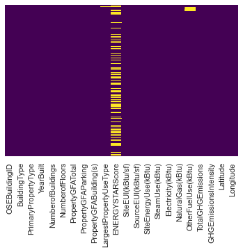

```python
sns.heatmap(data.isna(), yticklabels=False, cbar=False, cmap='viridis')
```

- Nous allons faire une imputation par KNN sur "ENERGYSTARScore"
- Pour la variable "OtherFuelUse(kBtu)", nous allons remplacer les valeurs manquantes par la moyenne
- Nous allons supprimer les lignes contenant les valeurs manquantes pour la variable "LargestPropertyUseType"

#### Traitement des valeurs aberrantes

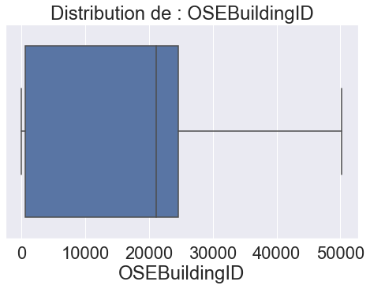

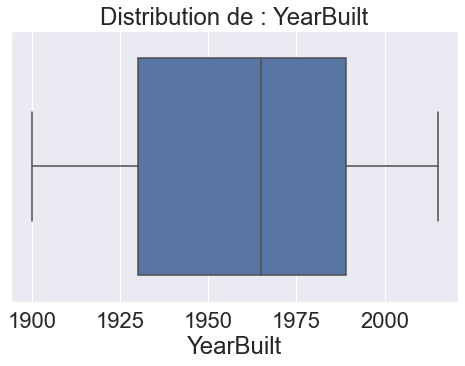

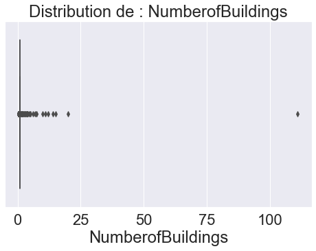

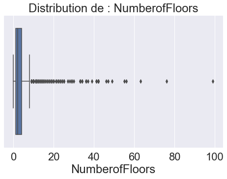

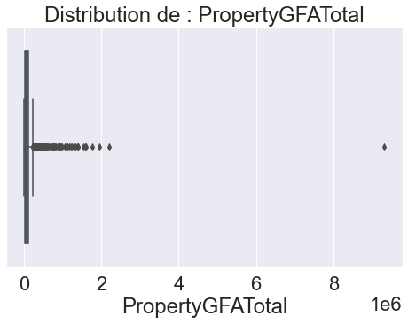

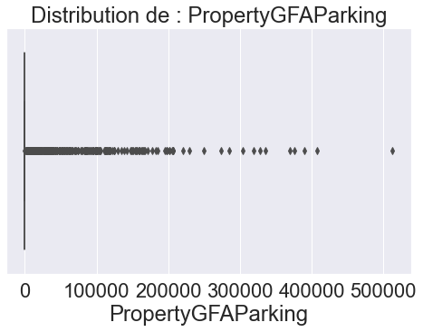

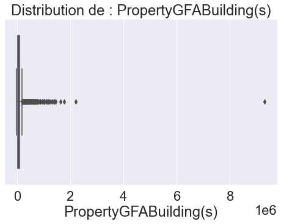

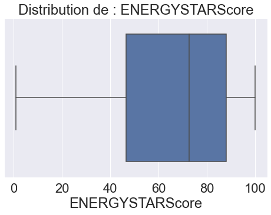

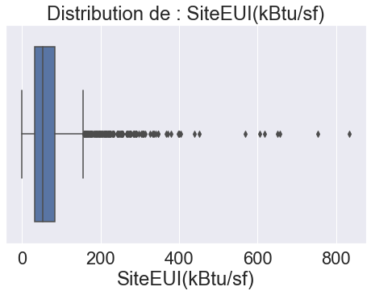

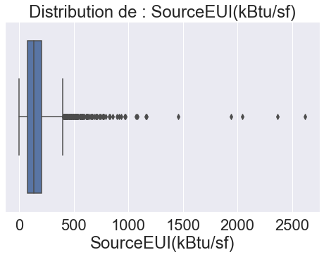

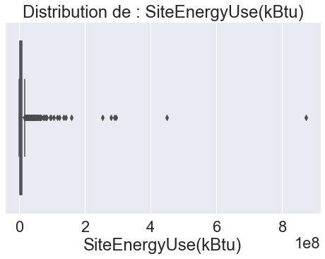

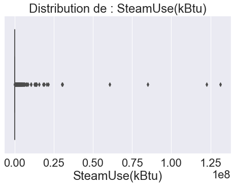

[7 more figures not shown]

```python
numeric_columns = data.select_dtypes(include = ['float64','int64']).columns
sns.set(font_scale=2)
for column in numeric_columns:
    plt.figure(figsize = (8,5))

    sns.boxplot(data[column])
    chaine = 'Distribution de : ' + column
    plt.title(chaine)
    plt.xlabel(column)
    plt.show()
sns.set(font_scale=1)
```

#### - Les valeurs négatives

En regardant les boites à moustaches, on a trouvé des valeurs négatives pour certaines variables. Donc, on va les supprimer

Pour les variables "PropertyGFABuilding(s)" et "PropertyGFAParking",nous allons donc supprimer les lignes avec les valeurs négatives.

```python
condition = (data['PropertyGFABuilding(s)'] < 0)
print('Je supprime', len(data.loc[condition]), 'ligne')
data = data.drop(data.loc[condition].index)

condition = (data['PropertyGFAParking'] < 0)
print('Je supprime', len(data.loc[condition]), 'ligne')
data = data.drop(data.loc[condition].index)
```

```
Je supprime 1 ligne
Je supprime 1 ligne
```

Suppression des lignes avec 0 étage, et plus de 76 étages

```python
condition = (data['NumberofFloors'] == 0)
print('Je supprime', len(data.loc[condition]), 'ligne')
data = data.drop(data.loc[condition].index)

condition = (data['NumberofFloors'] > 76)
print('Je supprime', len(data.loc[condition]), 'ligne')
data = data.drop(data.loc[condition].index)
```

```
Je supprime 16 ligne
Je supprime 1 ligne
```

Pour traiter les autres valeurs aberrantes, on utilise la méthode d'isolation forest

### Isolation forest

```python
from sklearn.ensemble import IsolationForest
```

On va supprimer les variables déjà traitées. On va enlever ‘ENERGYSTARScore', aussi pour la servir à notre analyse à la fin.

```python
feature_drop= data.drop(['OSEBuildingID','YearBuilt',
                         'NumberofFloors',
                         'Latitude','Longitude',
                         'ENERGYSTARScore',
                         'BuildingType','PrimaryPropertyType','LargestPropertyUseType'], axis=1).dropna()


clf = IsolationForest(random_state= 0).fit(feature_drop)

pd.DataFrame({'ouliers': clf.predict(feature_drop)}, index=feature_drop.index)

data['outliers'] = pd.Series(clf.predict(feature_drop), index=feature_drop.index)
```

```python
print('Je supprime', len(data.loc[data['outliers'] == -1]), 'outliers')
data = data.drop(data.loc[data['outliers'] == -1].index)
data = data.drop('outliers', axis=1)
```

```
Je supprime 107 outliers
```

### Remplaçons les valeurs NaN de "OtherFuelUse(kBtu)" par la moyenne

```python
data['OtherFuelUse(kBtu)'].fillna((data['OtherFuelUse(kBtu)'].mean()), inplace=True)
```

### Suppression des lignes avec NaN de "LargestPropertyUseType"

```python
data['LargestPropertyUseType'].isnull().sum()
```

```
12
```

```python
data.loc[pd.isna(data["LargestPropertyUseType"]), :].index
```

```
Int64Index([0, 5, 8, 17, 23, 26, 36, 422, 637, 1418, 1437, 1492], dtype='int64')
```

```python
index_with_nan= data.loc[pd.isna(data["LargestPropertyUseType"]), :].index
```

```python
data.drop(index_with_nan,0, inplace=True)
```

```python
data['LargestPropertyUseType'].isnull().sum()
```

```
0
```

```python
data.columns
```

```
Index(['OSEBuildingID', 'BuildingType', 'PrimaryPropertyType', 'YearBuilt',
       'NumberofBuildings', 'NumberofFloors', 'PropertyGFATotal',
       'PropertyGFAParking', 'PropertyGFABuilding(s)',
       'LargestPropertyUseType', 'ENERGYSTARScore', 'SiteEUI(kBtu/sf)',
       'SourceEUI(kBtu/sf)', 'SiteEnergyUse(kBtu)', 'SteamUse(kBtu)',
       'Electricity(kBtu)', 'NaturalGas(kBtu)', 'OtherFuelUse(kBtu)',
       'TotalGHGEmissions', 'GHGEmissionsIntensity', 'Latitude', 'Longitude'],
      dtype='object')
```

- ### Imputation par KNN sur "ENERGYSTARScore"

```python
from sklearn import neighbors
from sklearn.metrics import mean_squared_error
from math import sqrt
```

```python
data_train = data.loc[data['ENERGYSTARScore'].notnull(),]
data_test = data.loc[data['ENERGYSTARScore'].isnull(),]
```

```python
from sklearn.model_selection import train_test_split
train , test = train_test_split(data_train, test_size = 0.3)

x_train = train[['SiteEUI(kBtu/sf)',
       'SourceEUI(kBtu/sf)','SiteEnergyUse(kBtu)','SteamUse(kBtu)',
       'Electricity(kBtu)','NaturalGas(kBtu)','OtherFuelUse(kBtu)',
       'GHGEmissionsIntensity']]

y_train = train['ENERGYSTARScore']

x_test = test[['SiteEUI(kBtu/sf)',
       'SourceEUI(kBtu/sf)','SiteEnergyUse(kBtu)','SteamUse(kBtu)',
       'Electricity(kBtu)','NaturalGas(kBtu)','OtherFuelUse(kBtu)',
       'GHGEmissionsIntensity']]
y_test = test['ENERGYSTARScore']
x_predict = data_test[['SiteEUI(kBtu/sf)',
       'SourceEUI(kBtu/sf)','SiteEnergyUse(kBtu)','SteamUse(kBtu)',
       'Electricity(kBtu)','NaturalGas(kBtu)','OtherFuelUse(kBtu)',
       'GHGEmissionsIntensity']]
```

```python
rmse_val = []
for K in range(20):
    K = K+1
    model = neighbors.KNeighborsRegressor(n_neighbors = K)

    model.fit(x_train, y_train)
    pred=model.predict(x_test)
    error = sqrt(mean_squared_error(y_test,pred))
    rmse_val.append(error)
    print('RMSE value for k= ' , K , 'is:', error)
```

```
RMSE value for k=  1 is: 36.30112493885865
RMSE value for k=  2 is: 31.356789671679273
RMSE value for k=  3 is: 29.62505778640118
RMSE value for k=  4 is: 29.317744411599964
RMSE value for k=  5 is: 29.213852793605287
RMSE value for k=  6 is: 28.298665657309286
RMSE value for k=  7 is: 27.88649011534858
RMSE value for k=  8 is: 27.58961133188129
RMSE value for k=  9 is: 27.530397421274145
RMSE value for k=  10 is: 27.437647296444474
RMSE value for k=  11 is: 27.39932352096758
RMSE value for k=  12 is: 27.44225553103992
RMSE value for k=  13 is: 27.374805246103158
RMSE value for k=  14 is: 27.37651377564109
RMSE value for k=  15 is: 27.317647151415382
RMSE value for k=  16 is: 27.34068702437773
RMSE value for k=  17 is: 27.329777154918876
RMSE value for k=  18 is: 27.169399029894024
RMSE value for k=  19 is: 27.113255196042253
RMSE value for k=  20 is: 27.0352575166912
```

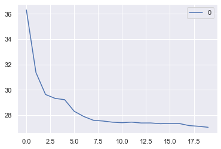

```python
curve = pd.DataFrame(rmse_val)
curve.plot()
```

```python
model = neighbors.KNeighborsRegressor(n_neighbors = 20)
```

```python
model.fit(x_train, y_train)
```

```
KNeighborsRegressor(n_neighbors=20)
```

```python
pred_ENERGYSTARScore = model.predict(x_predict)
```

```python
data.loc[data['ENERGYSTARScore'].isnull(), 'ENERGYSTARScore'] = pred_ENERGYSTARScore
```

```python
data['ENERGYSTARScore'].isnull().sum()
```

```
0
```

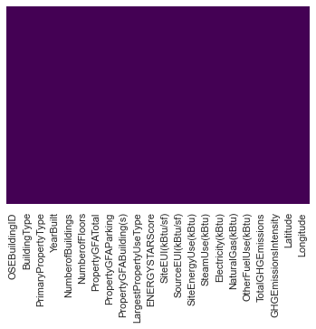

```python
sns.heatmap(data.isna(), yticklabels=False, cbar=False, cmap='viridis')
```

#### Ajout d'une variable de l'age de bâtiment

```python
# Obtenir l'année en cours
import datetime
current_year = datetime.datetime.now().year

# Calculer l'âge du bâtiment et l'enregistrer dans le DataFrame
data['BuildingAge'] = current_year - data['YearBuilt']

# Suppression de la colonne de 'YearBuilt'
data = data.drop(columns=['YearBuilt'])
```

```python
numeric_columns = data.select_dtypes(include = ['int64','float64']).columns
```

```python
numeric_columns
```

```
Index(['OSEBuildingID', 'NumberofBuildings', 'NumberofFloors',
       'PropertyGFATotal', 'PropertyGFAParking', 'PropertyGFABuilding(s)',
       'ENERGYSTARScore', 'SiteEUI(kBtu/sf)', 'SourceEUI(kBtu/sf)',
       'SiteEnergyUse(kBtu)', 'SteamUse(kBtu)', 'Electricity(kBtu)',
       'NaturalGas(kBtu)', 'OtherFuelUse(kBtu)', 'TotalGHGEmissions',
       'GHGEmissionsIntensity', 'Latitude', 'Longitude', 'BuildingAge'],
      dtype='object')
```

#### Distribution des variables numeriques

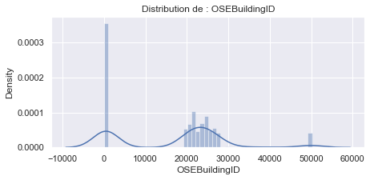

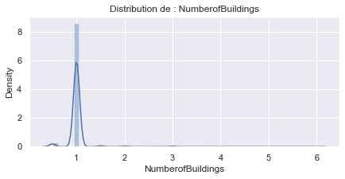

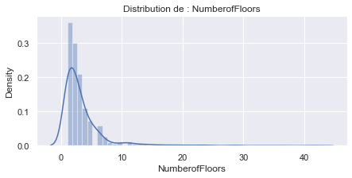

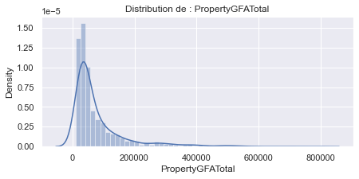

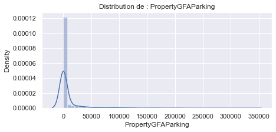

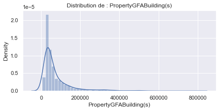

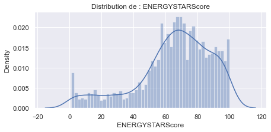

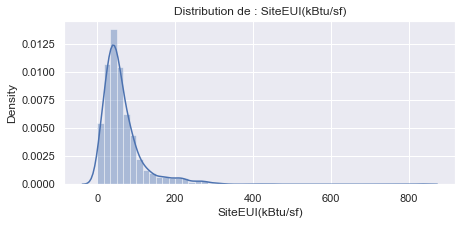

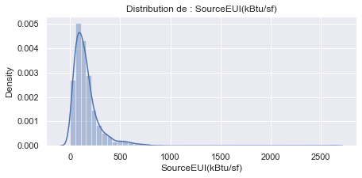

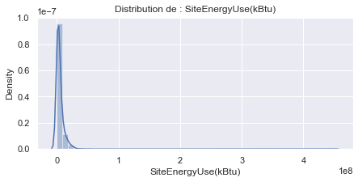

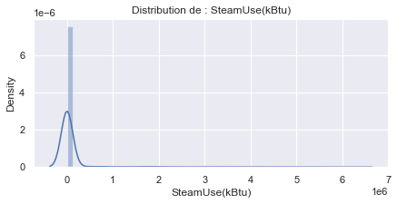

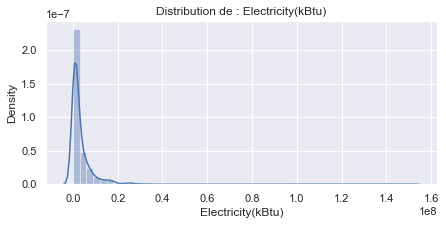

[7 more figures not shown]

```python
for column in numeric_columns:
    plt.figure(figsize = (7,3))
    sns.set(font_scale=1)
    sns.distplot(data[column], bins=50)
    chaine = 'Distribution de : ' + column
    plt.title(chaine)
    plt.xlabel(column)
    plt.show()
```

### Transformation logarithmique

On va faire une transformation logarithmique sur les variables cibles

```python
list_log = ['SiteEnergyUse(kBtu)','TotalGHGEmissions']
```

```python
for col in list_log:
  data[col] = np.log(data[col] + 1)  # +1 pour éviter des valeurs nulles
```

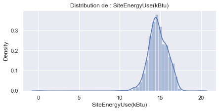

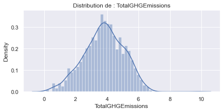

```python
for column in list_log:
    plt.figure(figsize = (7,3))
    sns.set(font_scale=1)
    sns.distplot(data[column], bins=50)
    chaine = 'Distribution de : ' + column
    plt.title(chaine)
    plt.xlabel(column)
    plt.show()
```

### Les variables categoriques

On va regarder les variables catégoriques

```python
category_columns = data.select_dtypes(include = ['object']).columns
```

```python
category_columns
```

```
Index(['BuildingType', 'PrimaryPropertyType', 'LargestPropertyUseType'], dtype='object')
```

#### BuildingType

```python
data['BuildingType'].value_counts().sort_values(ascending=False)
```

```
NonResidential        1365
SPS-District K-12       98
Nonresidential COS      80
Campus                  15
Nonresidential WA        1
Name: BuildingType, dtype: int64
```

- Nonresidential COS, et Nonresidential WA: Those are commercial buildings owned by City of Seattle(COS), and Washington State(WA) building.

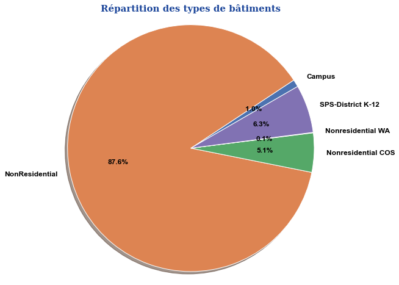

```python
building_type = data.groupby(by='BuildingType')['OSEBuildingID'].nunique()

font_title = {'family': 'serif',
              'color':  '#1d479b',
              'weight': 'bold',
              'size': 15,
             }

fig, ax = plt.subplots(figsize=(8,8))
ax.pie(building_type.values, labels=building_type.index,
       autopct='%1.1f%%', shadow=True, startangle=30,
       textprops=dict(color="black",size=12, weight="bold"))
ax.axis('equal')
ax.set_title("Répartition des types de bâtiments", fontdict=font_title)
plt.show()
```

On va les regrouper en 4 catégories

```python
Rename = {'NonResidential' : 'NonResidential','Nonresidential COS' : 'NonResidential','Campus':'Campus','SPS-District K-12': 'Education' }

data['BuildingType'] = data['BuildingType'].replace(Rename)
```

```python
data['BuildingType'].value_counts().sort_values(ascending=False)
```

```
NonResidential       1445
Education              98
Campus                 15
Nonresidential WA       1
Name: BuildingType, dtype: int64
```

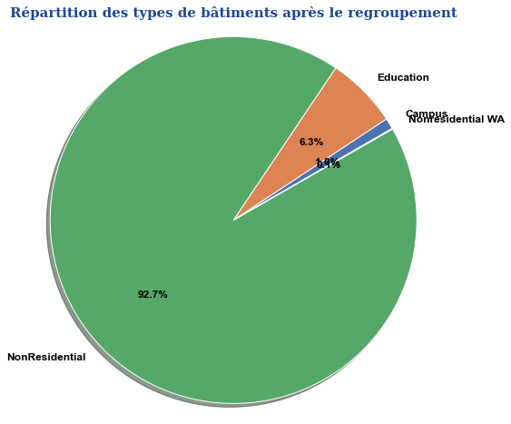

```python
building_type = data.groupby(by='BuildingType')['OSEBuildingID'].nunique()

font_title = {'family': 'serif',
              'color':  '#1d479b',
              'weight': 'bold',
              'size': 15,
             }

fig, ax = plt.subplots(figsize=(8,8))
ax.pie(building_type.values, labels=building_type.index,
       autopct='%1.1f%%', shadow=True, startangle=30,
       textprops=dict(color="black",size=12, weight="bold"))
ax.axis('equal')
ax.set_title("Répartition des types de bâtiments après le regroupement", fontdict=font_title)
plt.show()
```